# Visualizing OPUS binary files in R

#### Spectrum 34 : DRIFTS_Pot080_13Csoy_wk40_rhizoSoil_260702_COR.0

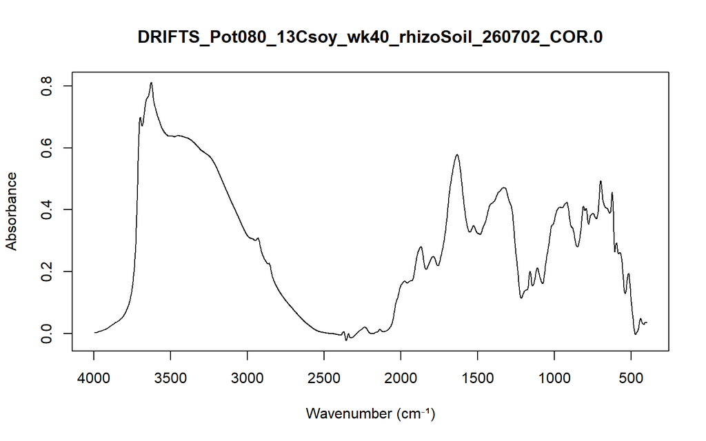

Metadata

| Parameter | Value |
| --- | --- |
| File Name | DRIFTS_Pot080_13Csoy_wk40_rhizoSoil_260702_COR.0 |
| Timestamp | 2026-07-02 13:46:42 GMT-7 |
| Max Y | 0.811241626739502 |
| Min Y | -0.0232980288565159 |
| Aperture Setting | 4 mm |
| Scanner Velocity | 10.0S |
| Result Spectrum | AB |
| Resolution | 4 |
| Sample Scans | 400 |
| End Frequency | 400 |
| Start Frequency | 4000 |
| Duration | 364.44384765625 |
| Experiment (method) | SALK_soils_method.xpm |

#### Spectrum 35 : DRIFTS_Pot087_13Crice_wk10_rhizoSoil_260624_COR.0

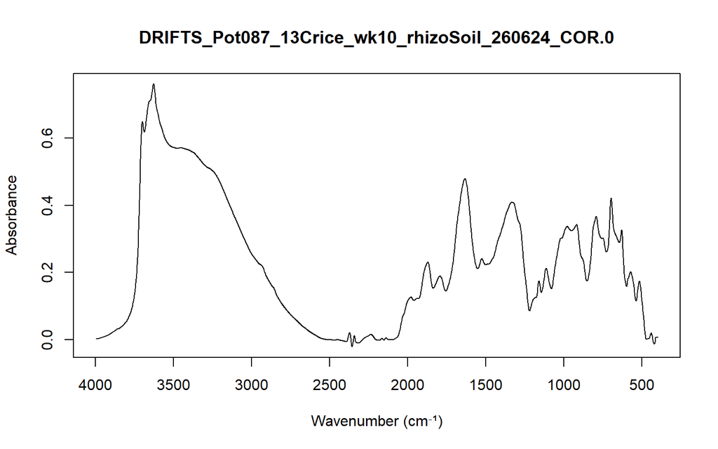

Metadata

| Parameter | Value |
| --- | --- |
| File Name | DRIFTS_Pot087_13Crice_wk10_rhizoSoil_260624_COR.0 |
| Timestamp | 2026-06-24 16:33:58 GMT-7 |
| Max Y | 0.761567890644073 |
| Min Y | -0.021226953715086 |
| Aperture Setting | 4 mm |
| Scanner Velocity | 10.0S |
| Result Spectrum | AB |
| Resolution | 4 |
| Sample Scans | 400 |
| End Frequency | 400 |
| Start Frequency | 4000 |
| Duration | 364.48876953125 |
| Experiment (method) | SALK_soils_method.xpm |

#### Spectrum 36 : DRIFTS_Pot087_13Crice_wk40_rhizoSoil_260702_COR.0

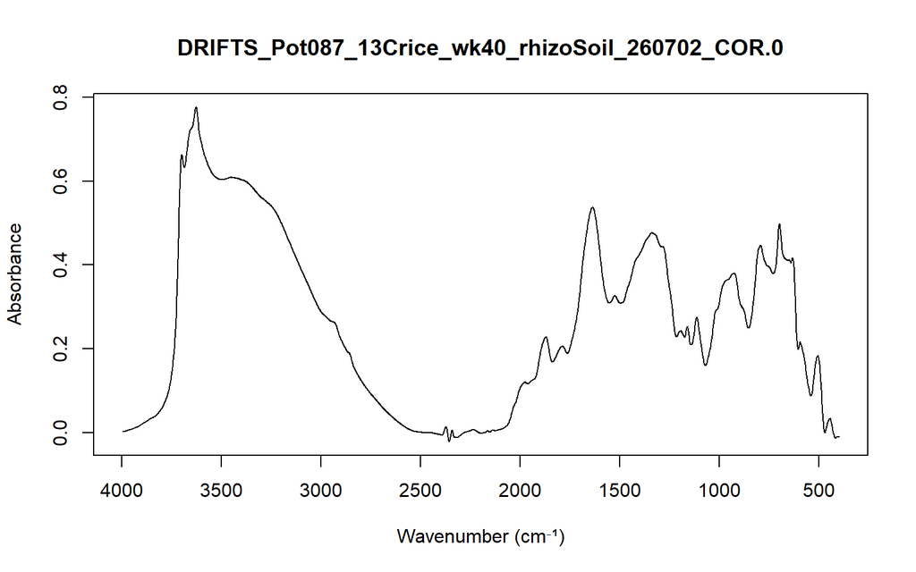

Metadata

| Parameter | Value |
| --- | --- |
| File Name | DRIFTS_Pot087_13Crice_wk40_rhizoSoil_260702_COR.0 |
| Timestamp | 2026-07-02 13:46:56 GMT-7 |
| Max Y | 0.777167320251465 |
| Min Y | -0.0222455728799105 |
| Aperture Setting | 4 mm |
| Scanner Velocity | 10.0S |
| Result Spectrum | AB |
| Resolution | 4 |
| Sample Scans | 400 |
| End Frequency | 400 |
| Start Frequency | 4000 |
| Duration | 364.43896484375 |
| Experiment (method) | SALK_soils_method.xpm |

#### Spectrum 37 : DRIFTS_Pot091_13CnoPlant_wk40_rhizoSoil_260617_COR.0

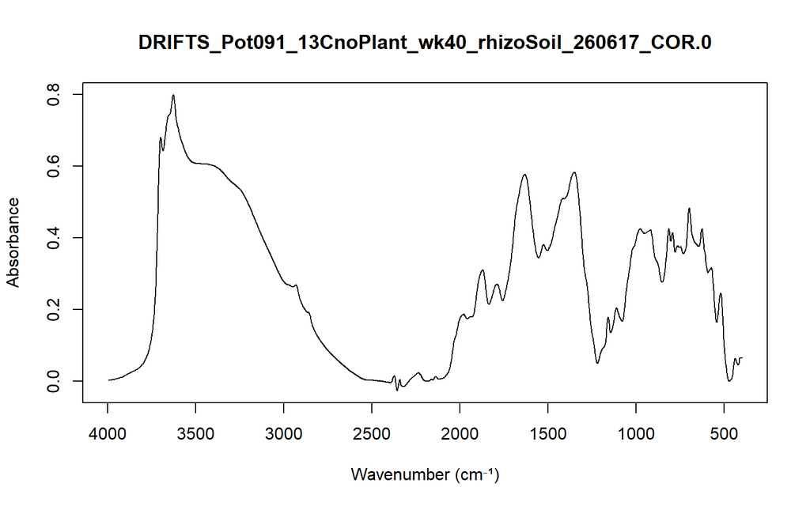

Metadata

| Parameter | Value |
| --- | --- |
| File Name | DRIFTS_Pot091_13CnoPlant_wk40_rhizoSoil_260617_COR.0 |
| Timestamp | 2026-06-17 17:14:58 GMT-7 |
| Max Y | 0.799693048000336 |
| Min Y | -0.0274133011698723 |
| Aperture Setting | 4 mm |
| Scanner Velocity | 10.0S |
| Result Spectrum | AB |
| Resolution | 4 |
| Sample Scans | 400 |
| End Frequency | 400 |
| Start Frequency | 4000 |
| Duration | 364.48388671875 |
| Experiment (method) | SALK_soils_method.xpm |

#### Spectrum 38 : DRIFTS_Pot094_13Csoy_wk10_rhizoSoil_260624A_COR.0

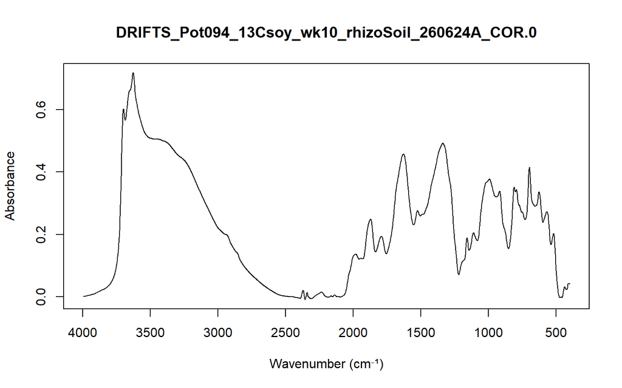

Metadata

| Parameter | Value |
| --- | --- |
| File Name | DRIFTS_Pot094_13Csoy_wk10_rhizoSoil_260624A_COR.0 |
| Timestamp | 2026-06-24 16:34:20 GMT-7 |
| Max Y | 0.718205392360687 |
| Min Y | -0.00935143232345581 |
| Aperture Setting | 4 mm |
| Scanner Velocity | 10.0S |
| Result Spectrum | AB |
| Resolution | 4 |
| Sample Scans | 400 |
| End Frequency | 400 |
| Start Frequency | 4000 |
| Duration | 364.48876953125 |
| Experiment (method) | SALK_soils_method.xpm |

#### Spectrum 39 : DRIFTS_Pot094_13Csoy_wk10_rhizoSoil_260624B_COR.0

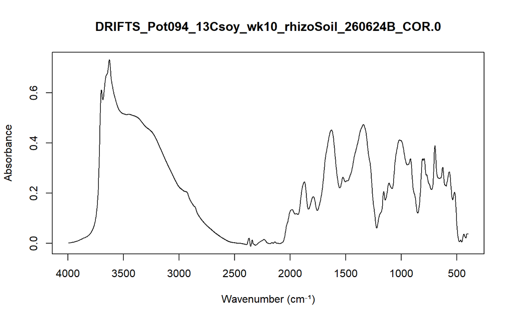

Metadata

| Parameter | Value |
| --- | --- |
| File Name | DRIFTS_Pot094_13Csoy_wk10_rhizoSoil_260624B_COR.0 |
| Timestamp | 2026-06-24 16:34:34 GMT-7 |
| Max Y | 0.732397437095642 |
| Min Y | -0.0123038925230503 |
| Aperture Setting | 4 mm |
| Scanner Velocity | 10.0S |
| Result Spectrum | AB |
| Resolution | 4 |
| Sample Scans | 400 |
| End Frequency | 400 |
| Start Frequency | 4000 |
| Duration | 364.468994140625 |
| Experiment (method) | SALK_soils_method.xpm |

#### Spectrum 40 : DRIFTS_Pot094_13Csoy_wk40_rhizoSoil_260702_COR.0

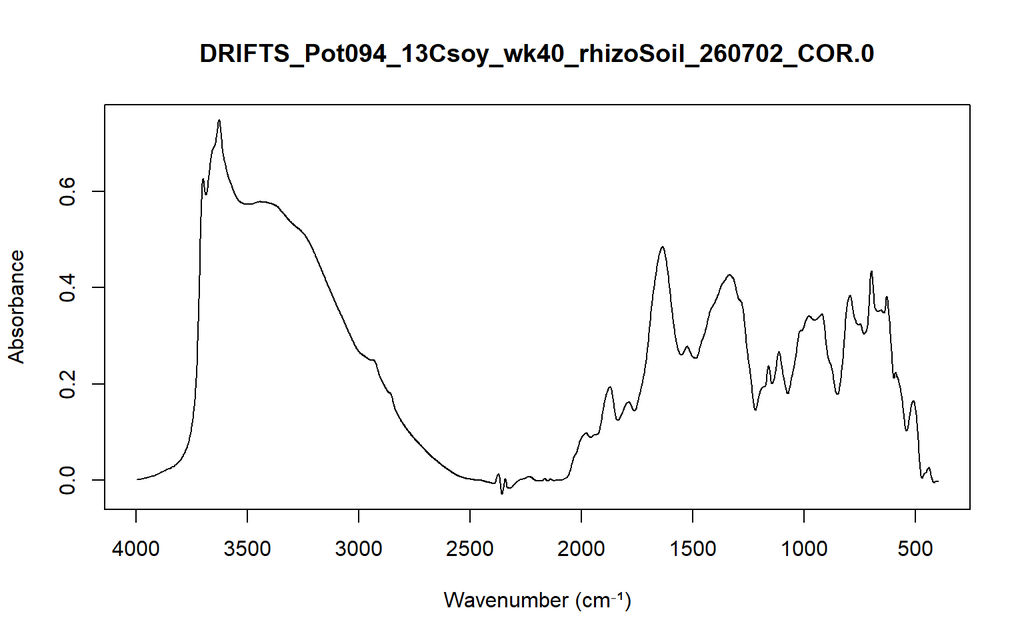

Metadata

| Parameter | Value |
| --- | --- |
| File Name | DRIFTS_Pot094_13Csoy_wk40_rhizoSoil_260702_COR.0 |
| Timestamp | 2026-07-02 13:47:09 GMT-7 |
| Max Y | 0.748205006122589 |
| Min Y | -0.0288987644016743 |
| Aperture Setting | 4 mm |
| Scanner Velocity | 10.0S |
| Result Spectrum | AB |
| Resolution | 4 |
| Sample Scans | 400 |
| End Frequency | 400 |
| Start Frequency | 4000 |
| Duration | 364.447998046875 |
| Experiment (method) | SALK_soils_method.xpm |

#### Spectrum 41 : DRIFTS_Pot103_13Crice_wk0_rhizoSoil_260618_COR.0

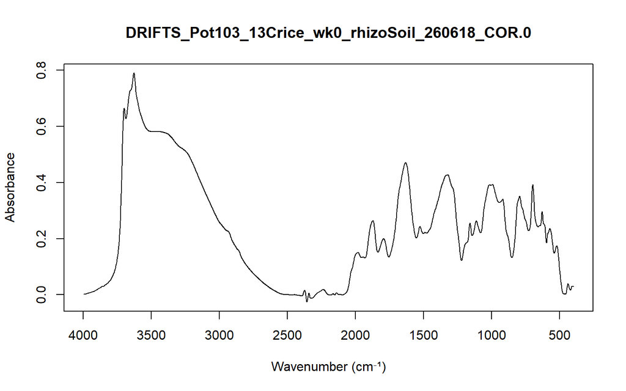

Metadata

| Parameter | Value |
| --- | --- |
| File Name | DRIFTS_Pot103_13Crice_wk0_rhizoSoil_260618_COR.0 |
| Timestamp | 2026-06-18 13:32:12 GMT-7 |
| Max Y | 0.789500772953033 |
| Min Y | -0.0259756669402122 |
| Aperture Setting | 4 mm |
| Scanner Velocity | 10.0S |
| Result Spectrum | AB |
| Resolution | 4 |
| Sample Scans | 400 |
| End Frequency | 400 |
| Start Frequency | 4000 |
| Duration | 364.48779296875 |
| Experiment (method) | SALK_soils_method.xpm |

#### Spectrum 42 : DRIFTS_Pot104_13Csoy_wk0_rhizoSoil_260618_COR.0

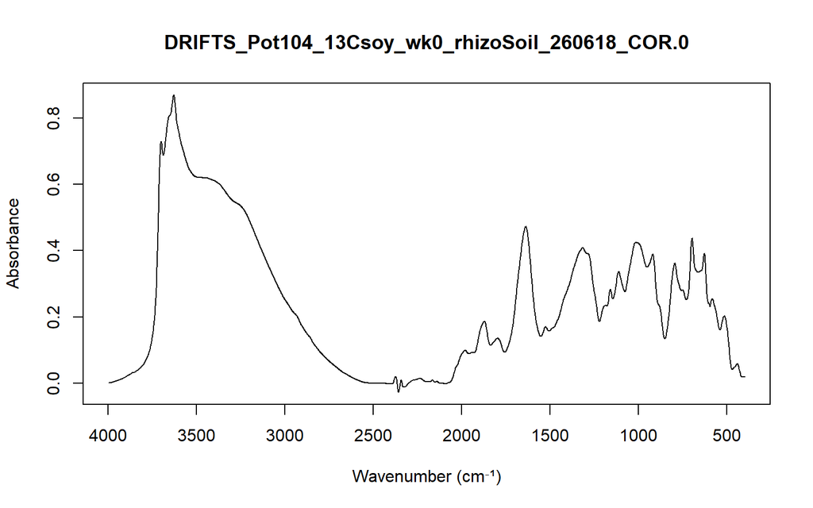

Metadata

| Parameter | Value |
| --- | --- |
| File Name | DRIFTS_Pot104_13Csoy_wk0_rhizoSoil_260618_COR.0 |
| Timestamp | 2026-06-18 13:32:24 GMT-7 |
| Max Y | 0.8695028424263 |
| Min Y | -0.0279160793870687 |
| Aperture Setting | 4 mm |
| Scanner Velocity | 10.0S |
| Result Spectrum | AB |
| Resolution | 4 |
| Sample Scans | 400 |
| End Frequency | 400 |
| Start Frequency | 4000 |
| Duration | 364.493896484375 |
| Experiment (method) | SALK_soils_method.xpm |

#### Spectrum 43 : DRIFTS_Pot108_12CnoPlant_wk40_rhizoSoil_260617_COR.0

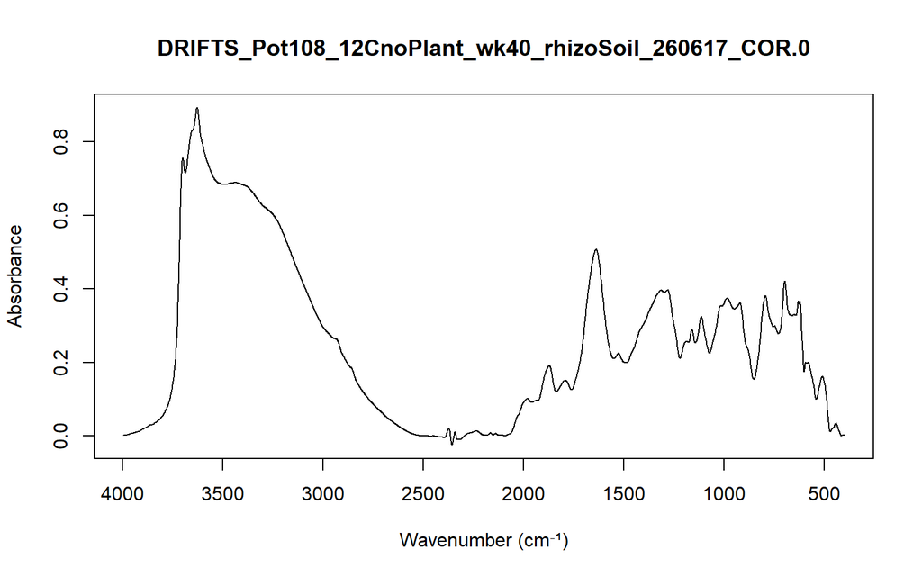

Metadata

| Parameter | Value |
| --- | --- |
| File Name | DRIFTS_Pot108_12CnoPlant_wk40_rhizoSoil_260617_COR.0 |
| Timestamp | 2026-06-17 13:44:34 GMT-7 |
| Max Y | 0.892604053020477 |
| Min Y | -0.0241758283227682 |
| Aperture Setting | 4 mm |
| Scanner Velocity | 10.0S |
| Result Spectrum | AB |
| Resolution | 4 |
| Sample Scans | 400 |
| End Frequency | 400 |
| Start Frequency | 4000 |
| Duration | 364.48388671875 |
| Experiment (method) | SALK_soils_method.xpm |

#### Spectrum 44 : DRIFTS_Pot109_13Cwheat_wk10_rhizoSoil_260624_COR.0

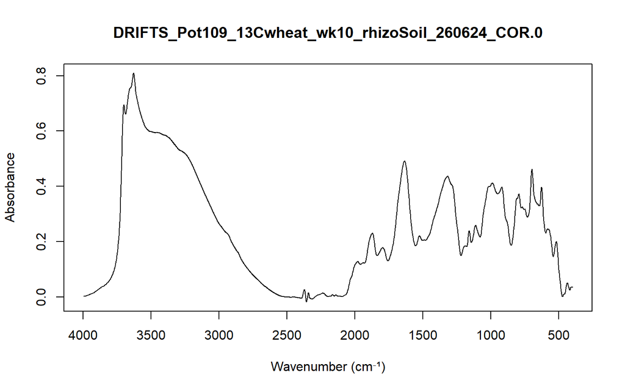

Metadata

| Parameter | Value |
| --- | --- |
| File Name | DRIFTS_Pot109_13Cwheat_wk10_rhizoSoil_260624_COR.0 |
| Timestamp | 2026-06-24 16:34:54 GMT-7 |
| Max Y | 0.809303522109985 |
| Min Y | -0.0182424057275057 |
| Aperture Setting | 4 mm |
| Scanner Velocity | 10.0S |
| Result Spectrum | AB |
| Resolution | 4 |
| Sample Scans | 400 |
| End Frequency | 400 |
| Start Frequency | 4000 |
| Duration | 364.490966796875 |
| Experiment (method) | SALK_soils_method.xpm |

#### Spectrum 45 : DRIFTS_Pot109_13Cwheat_wk10_rhizoSoil_260624a_COR.0

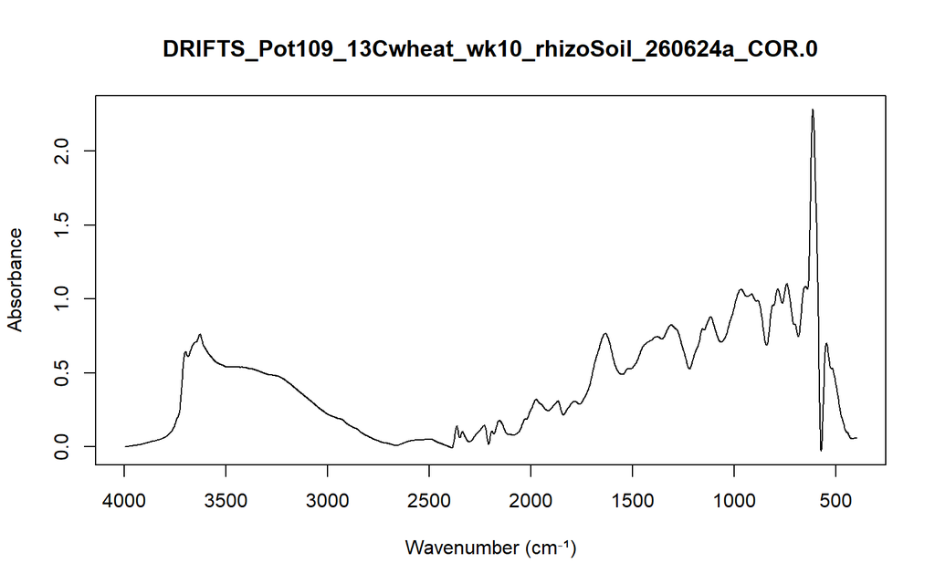

Metadata

| Parameter | Value |
| --- | --- |
| File Name | DRIFTS_Pot109_13Cwheat_wk10_rhizoSoil_260624a_COR.0 |
| Timestamp | 2026-06-24 16:35:07 GMT-7 |
| Max Y | 2.2838146686554 |
| Min Y | -0.0276018958538771 |
| Aperture Setting | 4 mm |
| Scanner Velocity | 10.0S |
| Result Spectrum | AB |
| Resolution | 4 |
| Sample Scans | 400 |
| End Frequency | 400 |
| Start Frequency | 4000 |
| Duration | 364.4658203125 |
| Experiment (method) | SALK_soils_method.xpm |

#### Spectrum 46 : DRIFTS_Pot109_13Cwheat_wk40_rhizoSoil_260702_COR.0

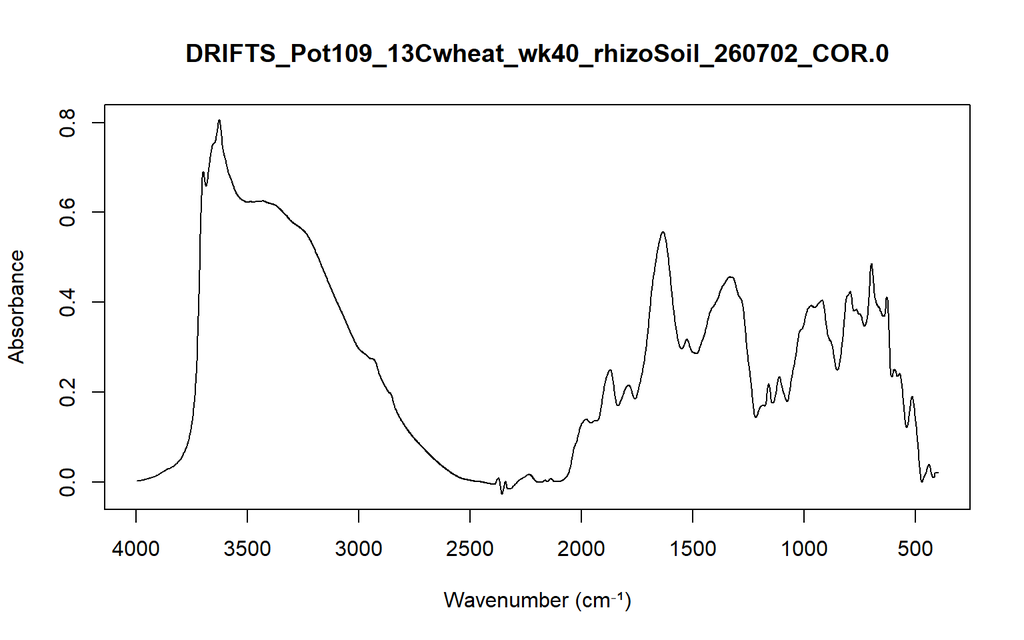

Metadata

| Parameter | Value |
| --- | --- |
| File Name | DRIFTS_Pot109_13Cwheat_wk40_rhizoSoil_260702_COR.0 |
| Timestamp | 2026-07-02 13:47:23 GMT-7 |
| Max Y | 0.806305408477783 |
| Min Y | -0.0276222322136164 |
| Aperture Setting | 4 mm |
| Scanner Velocity | 10.0S |
| Result Spectrum | AB |
| Resolution | 4 |
| Sample Scans | 400 |
| End Frequency | 400 |
| Start Frequency | 4000 |
| Duration | 364.454833984375 |
| Experiment (method) | SALK_soils_method.xpm |

#### Spectrum 47 : DRIFTS_Pot119_13Crice_wk10_rhizoSoil_260624A_COR.0

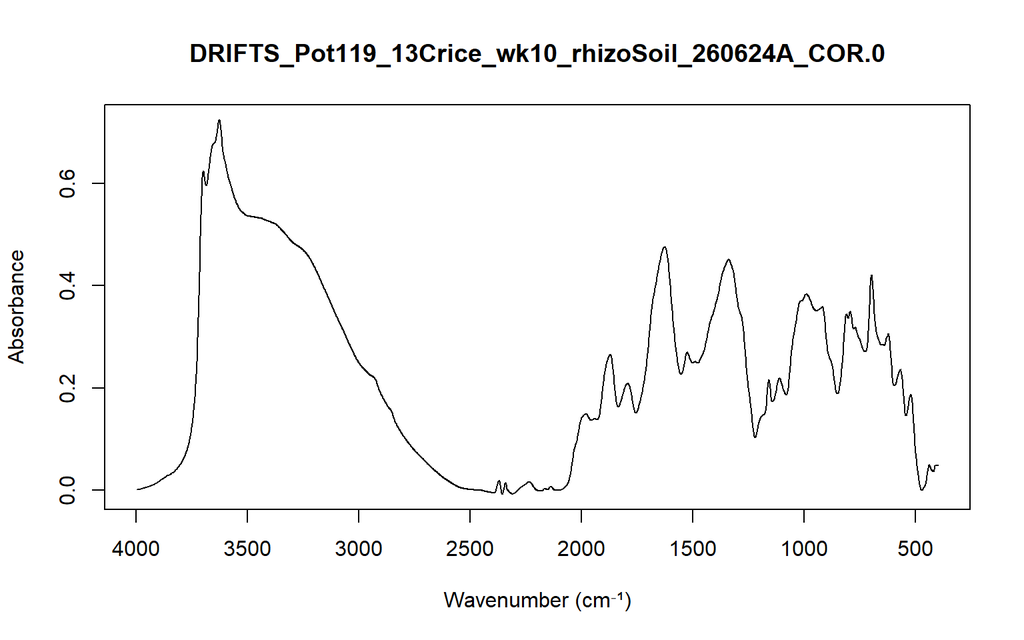

Metadata

| Parameter | Value |
| --- | --- |
| File Name | DRIFTS_Pot119_13Crice_wk10_rhizoSoil_260624A_COR.0 |
| Timestamp | 2026-06-24 16:35:32 GMT-7 |
| Max Y | 0.724849224090576 |
| Min Y | -0.00797996204346418 |
| Aperture Setting | 4 mm |
| Scanner Velocity | 10.0S |
| Result Spectrum | AB |
| Resolution | 4 |
| Sample Scans | 400 |
| End Frequency | 400 |
| Start Frequency | 4000 |
| Duration | 364.48486328125 |
| Experiment (method) | SALK_soils_method.xpm |

#### Spectrum 48 : DRIFTS_Pot119_13Crice_wk10_rhizoSoil_260624B_COR.0

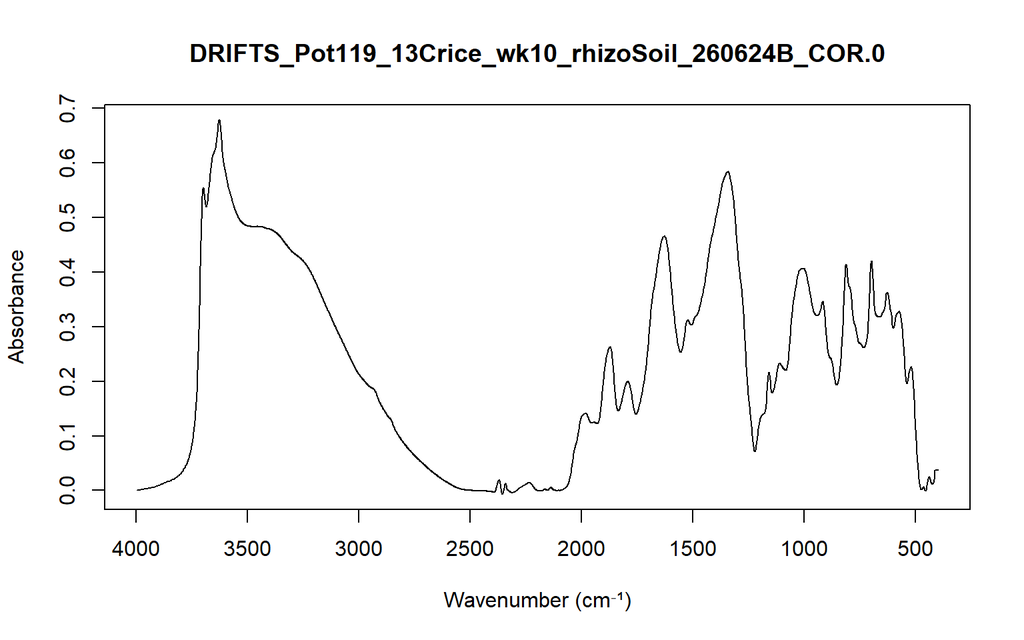

Metadata

| Parameter | Value |
| --- | --- |
| File Name | DRIFTS_Pot119_13Crice_wk10_rhizoSoil_260624B_COR.0 |
| Timestamp | 2026-06-24 16:35:48 GMT-7 |
| Max Y | 0.678993225097656 |
| Min Y | -0.00705508189275861 |
| Aperture Setting | 4 mm |
| Scanner Velocity | 10.0S |
| Result Spectrum | AB |
| Resolution | 4 |
| Sample Scans | 400 |
| End Frequency | 400 |
| Start Frequency | 4000 |
| Duration | 364.495849609375 |
| Experiment (method) | SALK_soils_method.xpm |

#### Spectrum 49 : DRIFTS_Pot119_13Crice_wk40_rhizoSoil_260702_COR.0

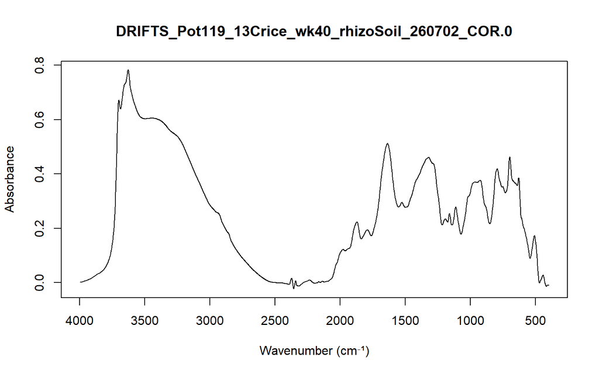

Metadata

| Parameter | Value |
| --- | --- |
| File Name | DRIFTS_Pot119_13Crice_wk40_rhizoSoil_260702_COR.0 |
| Timestamp | 2026-07-02 13:47:36 GMT-7 |
| Max Y | 0.78229546546936 |
| Min Y | -0.022571288049221 |
| Aperture Setting | 4 mm |
| Scanner Velocity | 10.0S |
| Result Spectrum | AB |
| Resolution | 4 |
| Sample Scans | 400 |
| End Frequency | 400 |
| Start Frequency | 4000 |
| Duration | 364.43896484375 |
| Experiment (method) | SALK_soils_method.xpm |

## Stacking multiple spectra

### Stacking re-runs

This code looks for files with the same sample number and stacks their spectra, to check whether reruns are consistent.

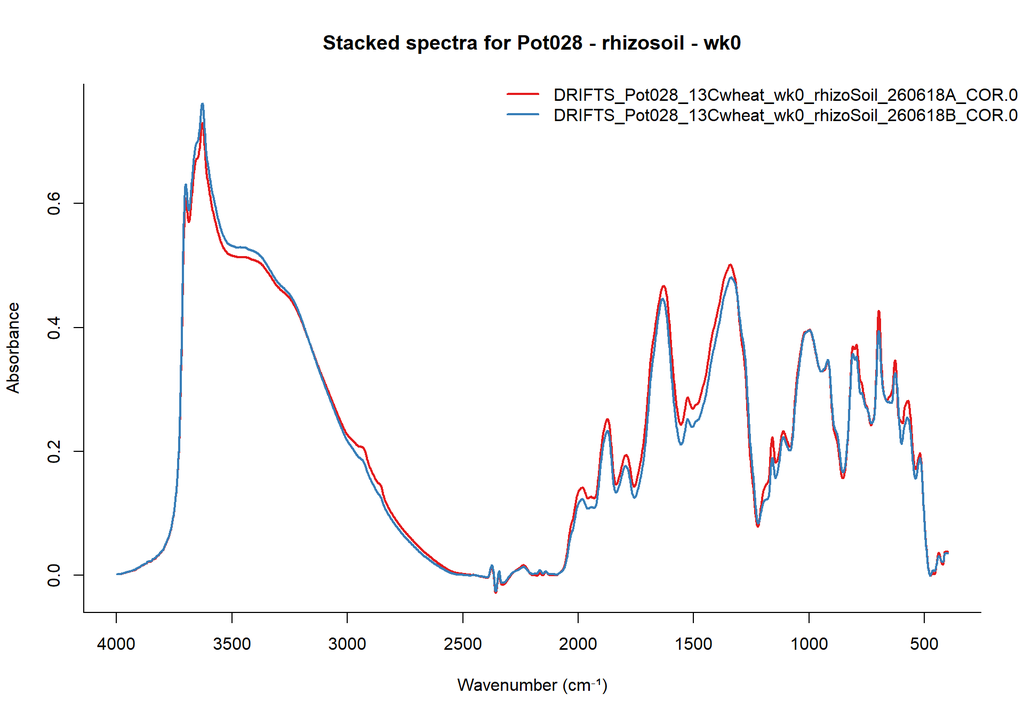

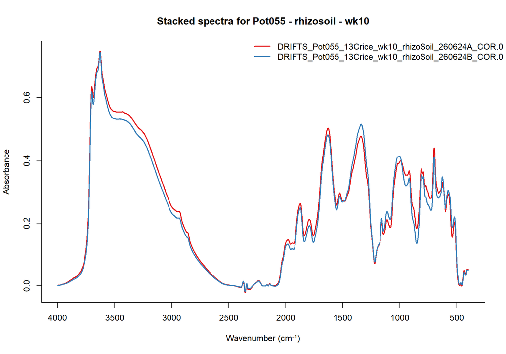

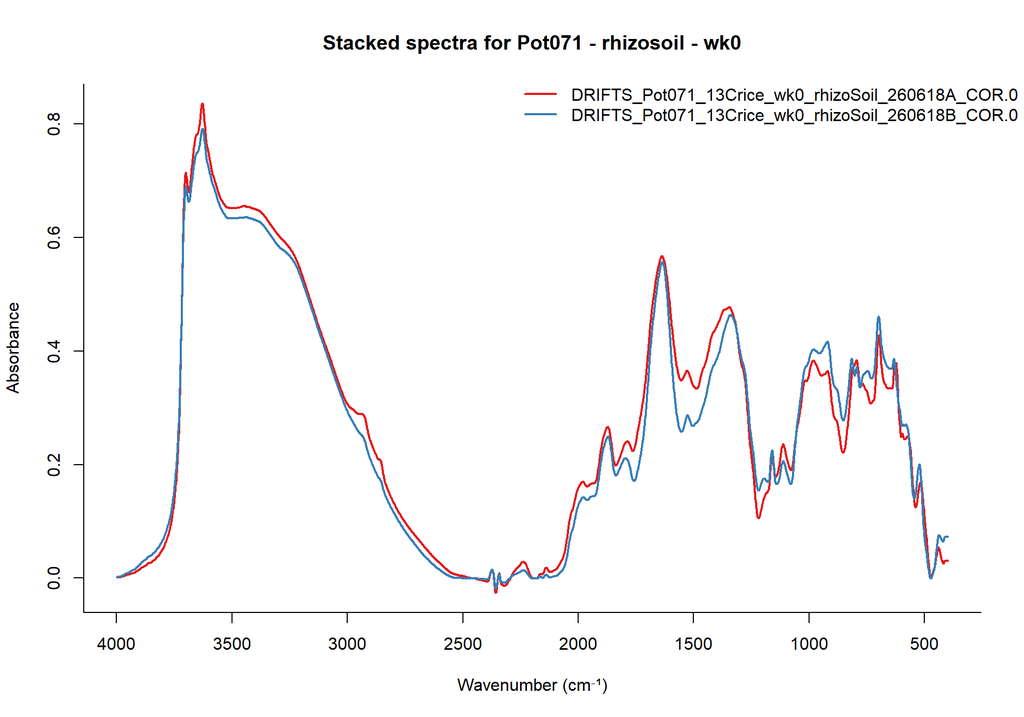

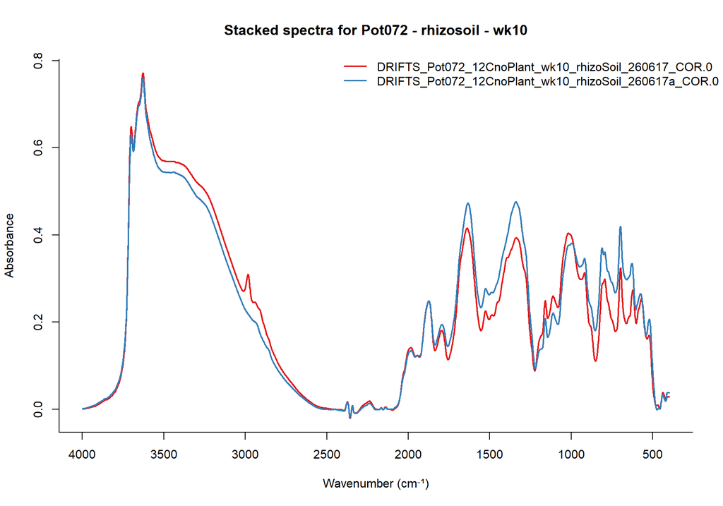

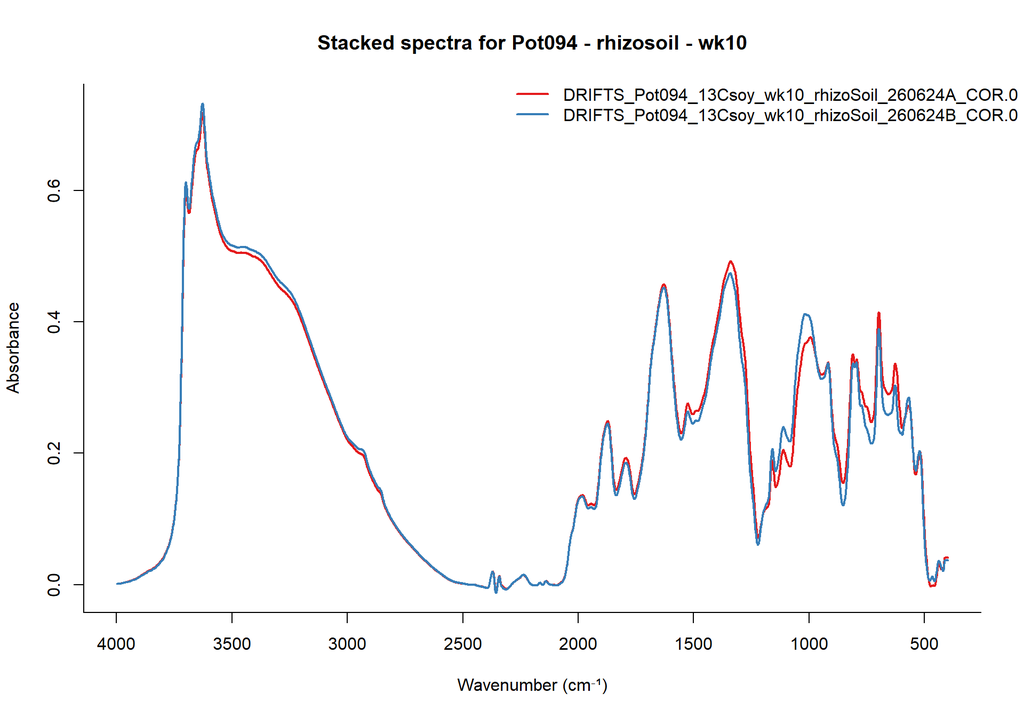

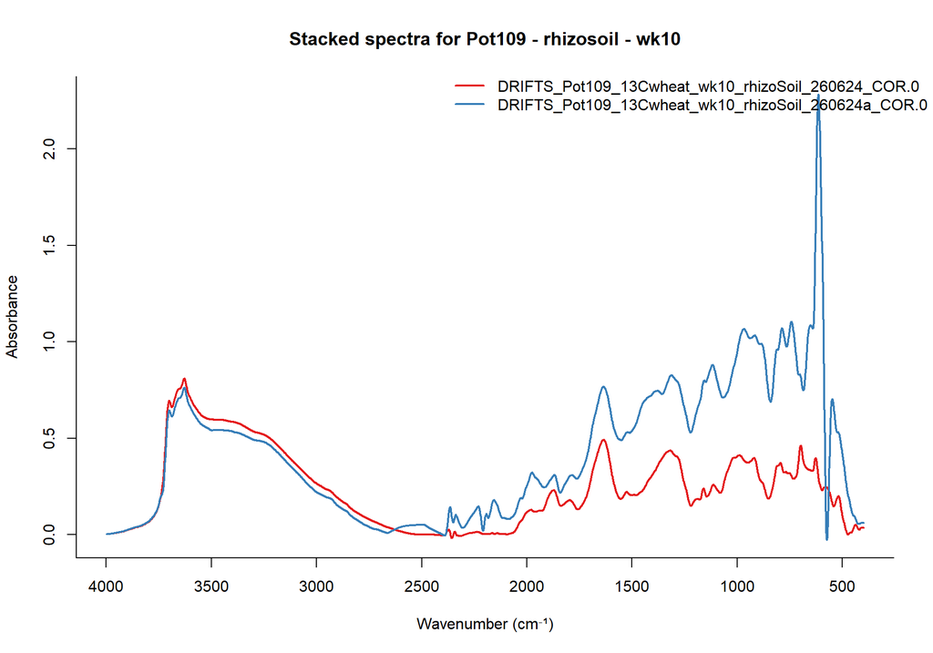

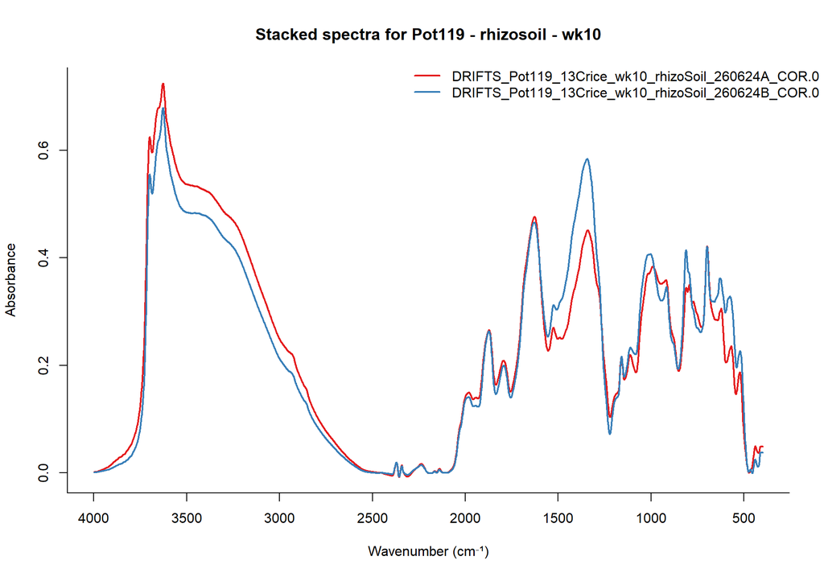

```r
knitr::opts_chunk$set(
  collapse = TRUE,
  comment = "#>",
  echo = TRUE,
  results = "markup",
  include = TRUE
)
library(opusreader2)
library(RColorBrewer)



data_test <- read_opus(dsn = corr_spectra)

# Helper to extract sample number from filename (e.g., "pot094")
extract_sample_number <- function(filename) {
  m <- regexpr("[A-Za-z]{3}[0-9]+", filename)
  if (m[1] != -1) {
    regmatches(filename, m)
  } else {
    NA
  }
}

# Helper to extract sample type (e.g.,"soil", "root")
extract_sample_type <- function(filename) {
  m <- regexpr("rhizoSoil|bulkSoil", filename, ignore.case = TRUE)
  if (m[1] != -1) {
    tolower(regmatches(filename, m))
  } else {
    NA
  }
}

# Helper to extract timepoint (e.g., "wk0", "wk40")
extract_timepoint <- function(filename) {
  m <- regexpr("wk[0-9]+", filename, ignore.case = TRUE)
  if (m[1] != -1) {
    tolower(regmatches(filename, m))
  } else {
    NA
  }
}

# Group files by sample number, sample type, and timepoint
sample_numbers <- sapply(names(data_test), extract_sample_number)
sample_types <- sapply(names(data_test), extract_sample_type)
timepoints <- sapply(names(data_test), extract_timepoint)

# Create unique combinations of sample number, sample type, and timepoint
sample_combinations <- paste(sample_numbers, sample_types, timepoints, sep = "_")
unique_combinations <- unique(sample_combinations[!is.na(sample_numbers)
                                                  & !is.na(sample_types)
                                                  & !is.na(timepoints)])

# Plot stacked spectra for each unique combination
library(RColorBrewer)
for (combination in unique_combinations) {
  idx <- which(sample_combinations == combination)
  if (length(idx) > 1) {
    # Extract sample number, type, and timepoint from combination
    parts <- strsplit(combination, "_")[[1]]
    sample_num <- parts[1]
    sample_type <- parts[2]
    timepoint <- parts[3]

    spectra <- data_test[idx]
    colors <- brewer.pal(min(length(spectra), 8), "Set1")
    plot(NULL, xlim = rev(range(spectra[[1]]$ab$wavenumbers)),
         ylim = range(sapply(spectra, function(x) x$ab$data), na.rm = TRUE),
         xlab = "Wavenumber (cm⁻¹)", ylab = "Absorbance",
         main = paste("Stacked spectra for", sample_num, "-", sample_type, "-", timepoint),
         bty = "l")
    for (i in seq_along(spectra)) {
      ab_data <- spectra[[i]]$ab
      if (!is.null(ab_data) && !is.null(ab_data$wavenumbers) &&
            !is.null(ab_data$data)) {
        lines(ab_data$wavenumbers, ab_data$data, col = colors[i], lwd = 2)
      }
    }
    legend("topright",
           inset = c(-0.05, -0.02),
           legend = names(spectra),
           col = colors[seq_along(spectra)],
           lwd = 2,
           xpd = TRUE,
           bty = "n")
  }
}
```

### Stacking by crop & time

This code stacks spectra of the same crop and timepoint.

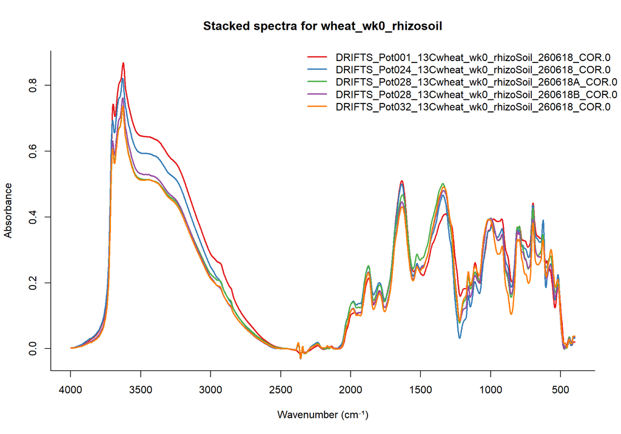

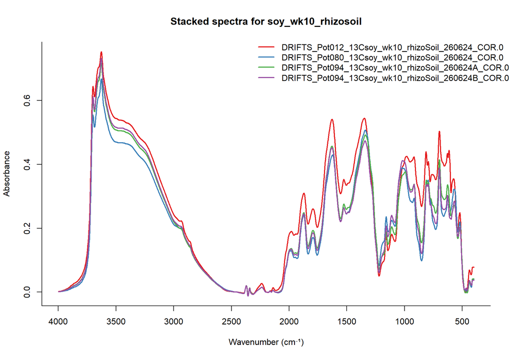

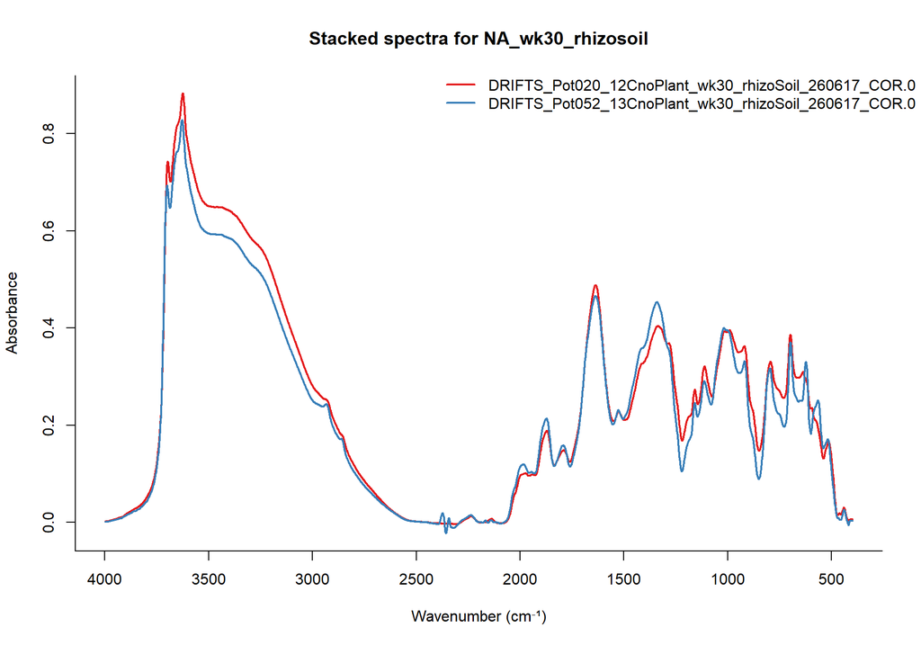

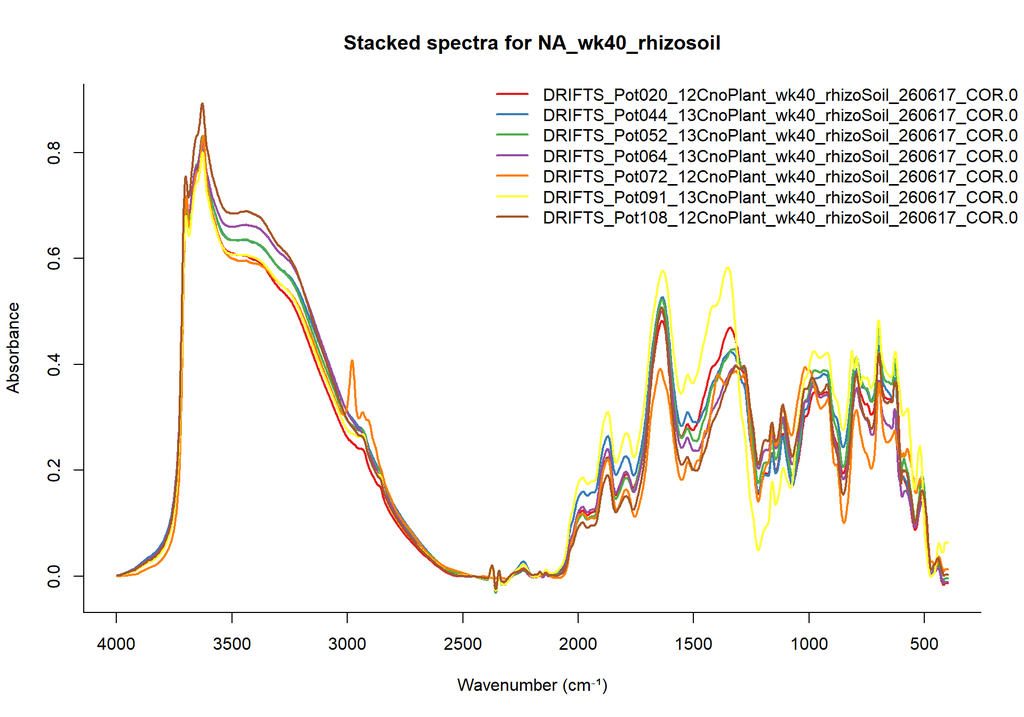

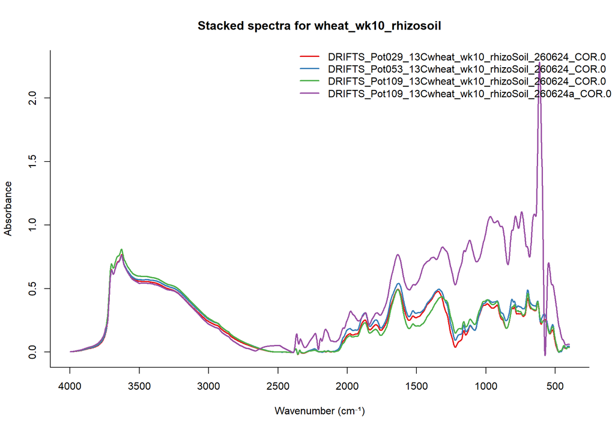

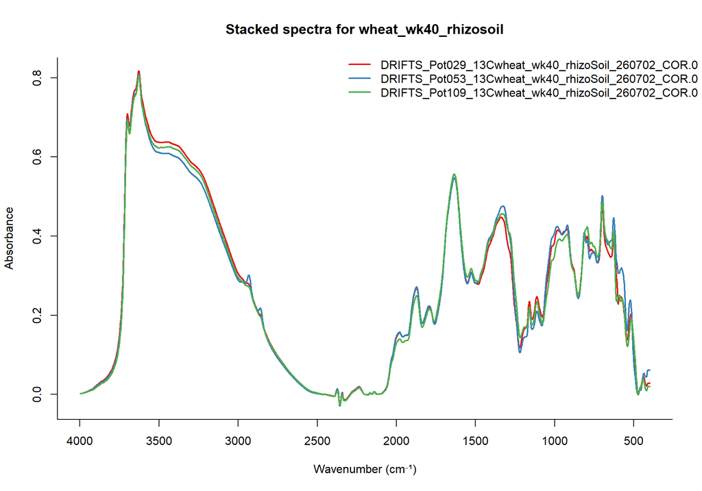

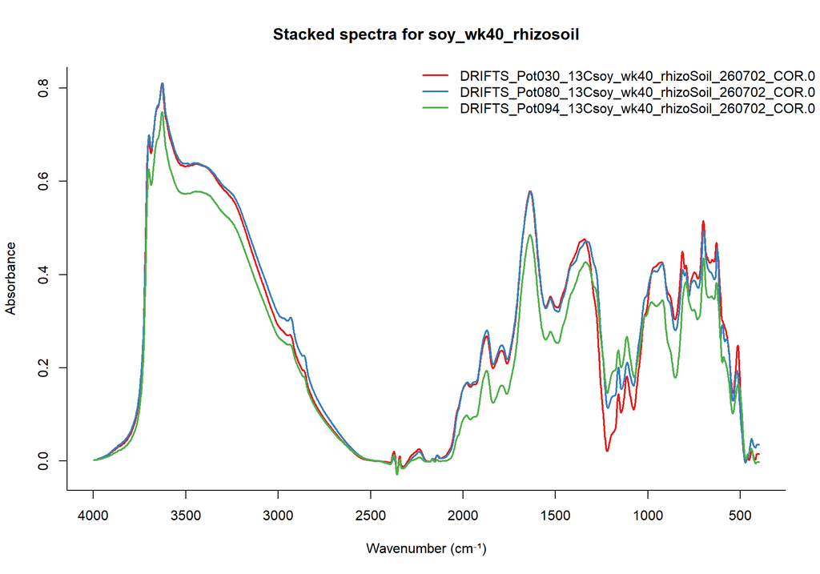

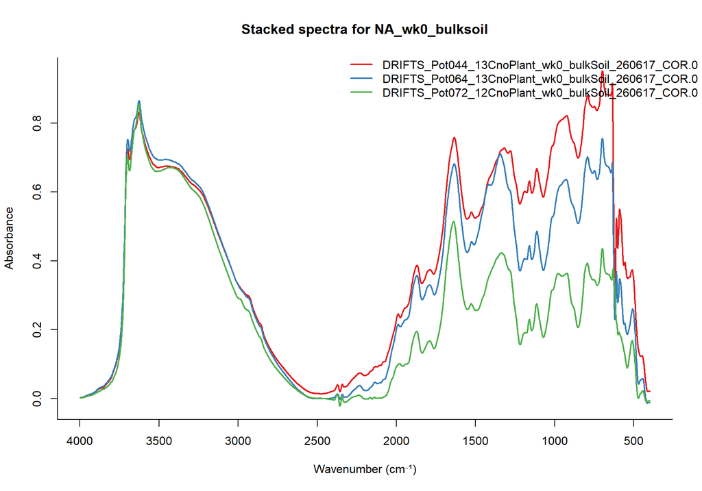

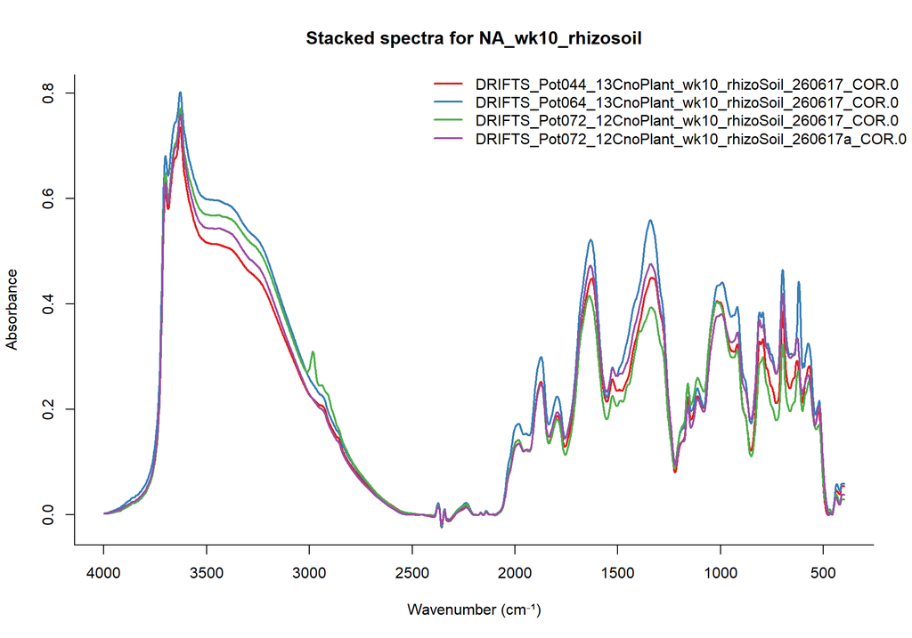

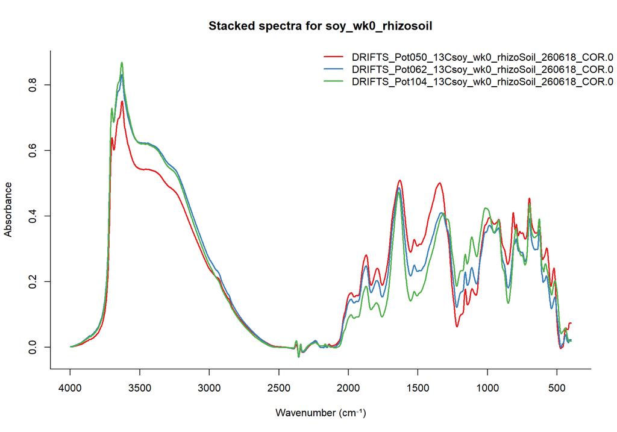

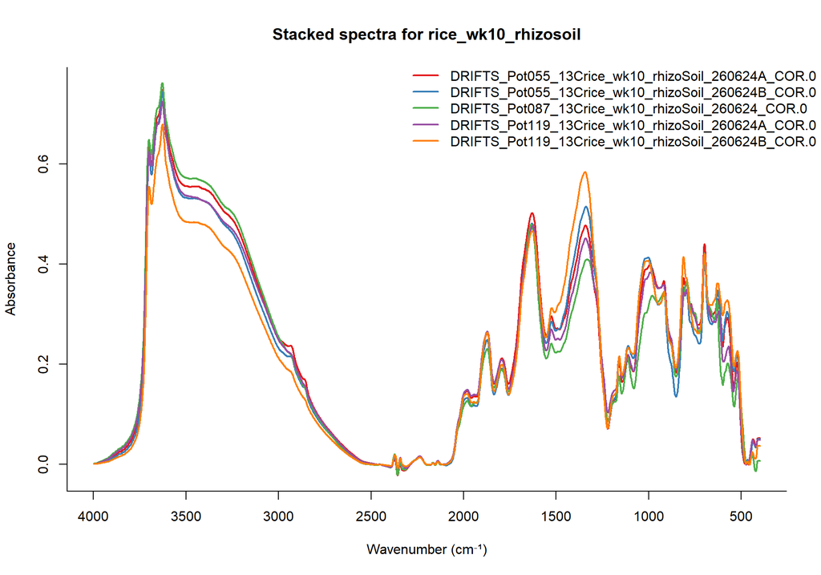

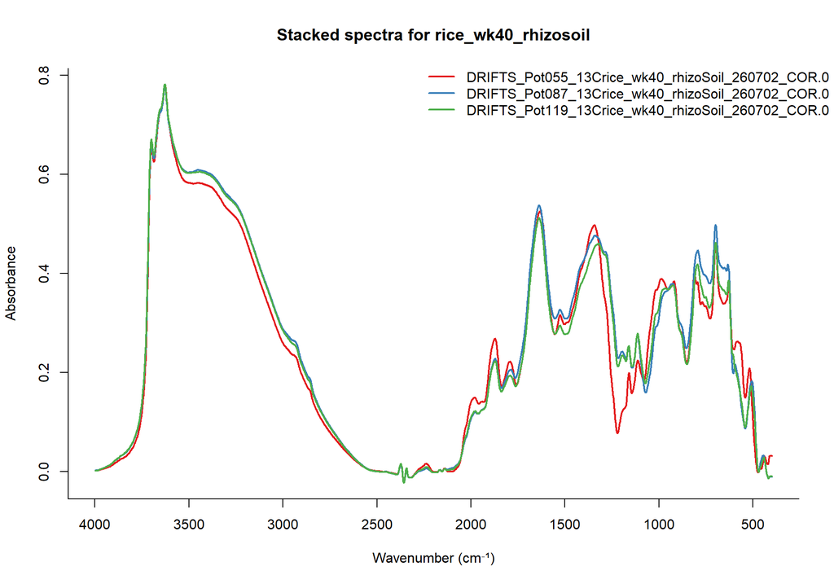

[1 more figures not shown]

```r
knitr::opts_chunk$set(
  collapse = TRUE,
  comment = "#>",
  echo = TRUE,
  results = "markup",
  include = TRUE
)
# Helper functions to extract crop and timepoint from filename
extract_crop <- function(filename) {
  m <- regexpr("rice|wheat|soy", filename, ignore.case = TRUE)
  if (m[1] != -1) tolower(regmatches(filename, m)) else NA
}
extract_time <- function(filename) {
  m <- regexpr("wk[0-9]+", filename, ignore.case = TRUE)
  if (m[1] != -1) tolower(regmatches(filename, m)) else NA
}
extract_sample_type <- function(filename) {
  m <- regexpr("rhizoSoil|bulkSoil", filename, ignore.case = TRUE)
  if (m[1] != -1) {
    tolower(regmatches(filename, m))
  } else {
    NA
  }
}
# Get crop and time for each file
crops <- sapply(names(data_test), extract_crop)
times <- sapply(names(data_test), extract_time)
types <- sapply(names(data_test), extract_sample_type)

# Unique crop-time combinations
combos <- na.omit(unique(paste(crops, times, types, sep = "_")))

library(RColorBrewer)
for (combo in combos) {
  idx <- which(paste(crops, times, types, sep = "_") == combo)
  if (length(idx) > 1) {
    spectra <- data_test[idx]
    colors <- brewer.pal(min(length(spectra), 8), "Set1")
    plot(NULL, xlim = rev(range(spectra[[1]]$ab$wavenumbers)),
         ylim = range(sapply(spectra, function(x) x$ab$data), na.rm = TRUE),
         xlab = "Wavenumber (cm⁻¹)", ylab = "Absorbance",
         main = paste("Stacked spectra for", combo),
         bty = "l")
    for (i in seq_along(spectra)) {
      ab_data <- spectra[[i]]$ab
      if (!is.null(ab_data) &&
            !is.null(ab_data$wavenumbers)
          && !is.null(ab_data$data)) {
        lines(ab_data$wavenumbers, ab_data$data, col = colors[i], lwd = 2)
      }
    }
    legend("topright",
           inset = c(-0.05, -0.02),
           legend = names(spectra),
           col = colors[seq_along(spectra)],
           lwd = 2,
           xpd = TRUE,
           bty = "n")
  }
}
```